# analysis

```r
library(ggplot2)
library(plyr)
library(dplyr)
library(corrplot)
library(caret)
library(gridExtra)
library(scales)
library(Rmisc)
library(ggrepel)
library(psych)
```

```r
#read in all.rds(output from feature engineering.Rmd)
all<-readRDS("all_DP.rds")
```

Preview cleaned data

```r
#to preview data prepared after cleaning
head(all)
```

|  | MSSubClass | MSZoning | LotFrontage | LotArea | Street | Alley | LotShape | LandContour | LotConfig | LandSlope | Neighborhood | Condition1 | Condition2 | BldgType | HouseStyle | OverallQual | OverallCond | YearBuilt | YearRemodAdd | RoofStyle | RoofMatl | Exterior1st | Exterior2nd | MasVnrType | MasVnrArea | ExterQual | ExterCond | Foundation | BsmtQual | … |
| --- | --- | --- | --- | --- | --- | --- | --- | --- | --- | --- | --- | --- | --- | --- | --- | --- | --- | --- | --- | --- | --- | --- | --- | --- | --- | --- | --- | --- | --- | --- |
| 1 | 60 | RL | 65 | 8450 | 1 | No alley access | 3 | Lvl | Inside | 2 | CollgCr | Norm | Norm | 1Fam | 2Story | 7 | 5 | 2003 | 2003 | Gable | CompShg | VinylSd | VinylSd | 2 | 196 | 3 | 2 | PConc | 4 | … |
| 2 | 20 | RL | 80 | 9600 | 1 | No alley access | 3 | Lvl | FR2 | 2 | Veenker | Feedr | Norm | 1Fam | 1Story | 6 | 8 | 1976 | 1976 | Gable | CompShg | MetalSd | MetalSd | 1 | 0 | 2 | 2 | CBlock | 4 | … |
| 3 | 60 | RL | 68 | 11250 | 1 | No alley access | 2 | Lvl | Inside | 2 | CollgCr | Norm | Norm | 1Fam | 2Story | 7 | 5 | 2001 | 2002 | Gable | CompShg | VinylSd | VinylSd | 2 | 162 | 3 | 2 | PConc | 4 | … |
| 4 | 70 | RL | 60 | 9550 | 1 | No alley access | 2 | Lvl | Corner | 2 | Crawfor | Norm | Norm | 1Fam | 2Story | 7 | 5 | 1915 | 1970 | Gable | CompShg | Wd Sdng | Wd Shng | 1 | 0 | 2 | 2 | BrkTil | 3 | … |
| 5 | 60 | RL | 84 | 14260 | 1 | No alley access | 2 | Lvl | FR2 | 2 | NoRidge | Norm | Norm | 1Fam | 2Story | 8 | 5 | 2000 | 2000 | Gable | CompShg | VinylSd | VinylSd | 2 | 350 | 3 | 2 | PConc | 4 | … |
| 6 | 50 | RL | 85 | 14115 | 1 | No alley access | 2 | Lvl | Inside | 2 | Mitchel | Norm | Norm | 1Fam | 1.5Fin | 5 | 5 | 1993 | 1995 | Gable | CompShg | VinylSd | VinylSd | 1 | 0 | 2 | 2 | Wood | 4 | … |

Categirized variavle based on data type

```r
numericVars <- which(sapply(all, is.numeric)) #index vector numeric variables
factorVars <- which(sapply(all, is.factor)) #index vector factor variables
cat('There are', length(numericVars), 'numeric variables, and', length(factorVars), 'categoric variables')
```

```
There are 56 numeric variables, and 23 categoric variables
```

Correlation again, Correlation plotted is different from previous part.

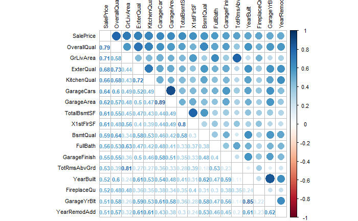

```r
#Plot correlation
all_numVar <- all[, numericVars]
cor_numVar <- cor(all_numVar, use="pairwise.complete.obs") #correlations of all numeric variables
#sort on decreasing correlations with SalePrice
cor_sorted <- as.matrix(sort(cor_numVar[,'SalePrice'], decreasing = TRUE))
 #select only high corelations
CorHigh <- names(which(apply(cor_sorted, 1, function(x) abs(x)>0.5)))
cor_numVar <- cor_numVar[CorHigh, CorHigh]
corrplot.mixed(cor_numVar, tl.col="black", tl.pos = "lt", tl.cex = 0.7,cl.cex = .7, number.cex=.7)
```

By doing with QUICK RANDOM FOREST, we picked top 20 most important variables.

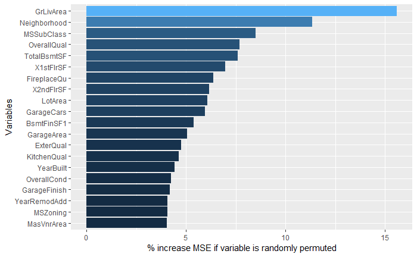

```r
library(randomForest)
set.seed(2018)
quick_RF <- randomForest(x=all[1:1460,-79], y=all$SalePrice[1:1460], ntree=100,importance=TRUE)
imp_RF <- importance(quick_RF)
imp_DF <- data.frame(Variables = row.names(imp_RF), MSE = imp_RF[,1])
imp_DF <- imp_DF[order(imp_DF$MSE, decreasing = TRUE),]
ggplot(imp_DF[1:20,], aes(x=reorder(Variables, MSE), y=MSE, fill=MSE)) + geom_bar(stat = 'identity') + labs(x = 'Variables', y= '% increase MSE if variable is randomly permuted') + coord_flip() + theme(legend.position="none")
```

According to random forest, there are top 3 most important of categorical features, Neighborhood, MSSubclass. The rest of top 20 variables are mostly numerical features.

Now, lets dig in on those top 3 variables. ############################# Most important variable #1: Neighborhood ########################################

Here, the first chart (blue) is explaining median of Sales price vs Neighborhood The second cghart is explainng about the frequency of neighborhood across all records (rows) in our data.

```r
n1 <- ggplot(all[!is.na(all$SalePrice),], aes(x=Neighborhood, y=SalePrice)) +
        geom_bar(stat='summary', fun.y = "median", fill='blue') +
        theme(axis.text.x = element_text(angle = 45, hjust = 1)) +
        scale_y_continuous(breaks= seq(0, 800000, by=50000), labels = comma) +
        geom_label(stat = "count", aes(label = ..count.., y = ..count..), size=3) +
        geom_hline(yintercept=163000, linetype="dashed", color = "red") #dashed line is median SalePrice
n2 <- ggplot(data=all, aes(x=Neighborhood)) +
        geom_histogram(stat='count')+
        geom_label(stat = "count", aes(label = ..count.., y = ..count..), size=3)+
        theme(axis.text.x = element_text(angle = 45, hjust = 1))
```

```
Ignoring unknown parameters: binwidth, bins, pad
```

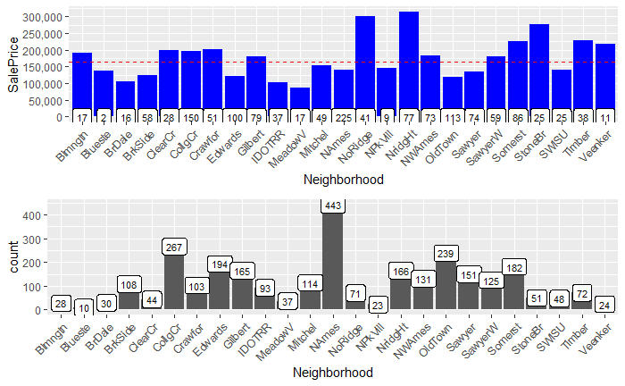

```r
grid.arrange(n1, n2)
```

Visualizing for Overall Quality vs other quality variables

```r
q1 <- ggplot(data=all, aes(x=as.factor(OverallQual))) +
        geom_histogram(stat='count')
```

```
Ignoring unknown parameters: binwidth, bins, pad
```

```r
q2 <- ggplot(data=all, aes(x=as.factor(ExterQual))) +
        geom_histogram(stat='count')
```

```
Ignoring unknown parameters: binwidth, bins, pad
```

```r
q3 <- ggplot(data=all, aes(x=as.factor(BsmtQual))) +
        geom_histogram(stat='count')
```

```
Ignoring unknown parameters: binwidth, bins, pad
```

```r
q4 <- ggplot(data=all, aes(x=as.factor(KitchenQual))) +
        geom_histogram(stat='count')
```

```
Ignoring unknown parameters: binwidth, bins, pad
```

```r
q5 <- ggplot(data=all, aes(x=as.factor(GarageQual))) +
        geom_histogram(stat='count')
```

```
Ignoring unknown parameters: binwidth, bins, pad
```

```r
q6 <- ggplot(data=all, aes(x=as.factor(FireplaceQu))) +
        geom_histogram(stat='count')
```

```
Ignoring unknown parameters: binwidth, bins, pad
```

```r
q7 <- ggplot(data=all, aes(x=as.factor(PoolQC))) +
        geom_histogram(stat='count')
```

```
Ignoring unknown parameters: binwidth, bins, pad
```

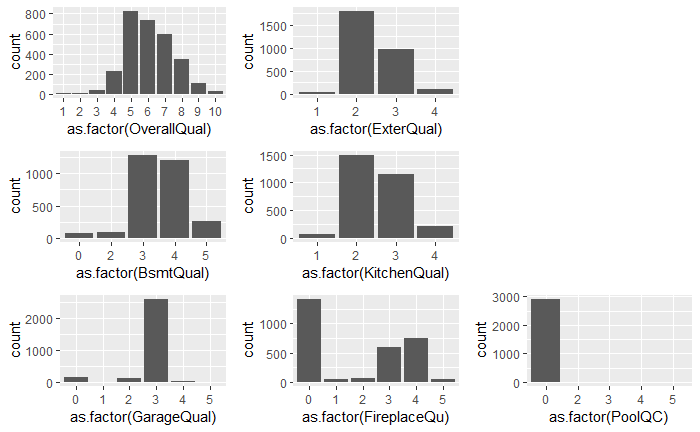

```r
layout <- matrix(c(1,2,8,3,4,8,5,6,7),3,3,byrow=TRUE)
multiplot(q1, q2, q3, q4, q5, q6, q7, layout=layout)
```

Overall quality shown more granular and more variations. Hence high correlation (0.73) is shown by more granular bar chart, so is kitchen qual. Pool QC have high count but variance is almost 0

Most important variable #2: MSSubClass

Same as previous chart, first chart showed how second most categoric variable influence Sales price-shown with median.

Second bar chart explained about the frequency of variance of MSSubclass across all data records.

```r
ms1 <- ggplot(all[!is.na(all$SalePrice),], aes(x=MSSubClass, y=SalePrice)) +
        geom_bar(stat='summary', fun.y = "median", fill='blue') +
        theme(axis.text.x = element_text(angle = 45, hjust = 1)) +
        scale_y_continuous(breaks= seq(0, 800000, by=50000), labels = comma) +
        geom_label(stat = "count", aes(label = ..count.., y = ..count..), size=3) +
        geom_hline(yintercept=163000, linetype="dashed", color = "red") #dashed line is median SalePrice
ms2 <- ggplot(data=all, aes(x=MSSubClass)) +
        geom_histogram(stat='count')+
        geom_label(stat = "count", aes(label = ..count.., y = ..count..), size=3) +
        theme(axis.text.x = element_text(angle = 45, hjust = 1))
```

```
Ignoring unknown parameters: binwidth, bins, pad
```

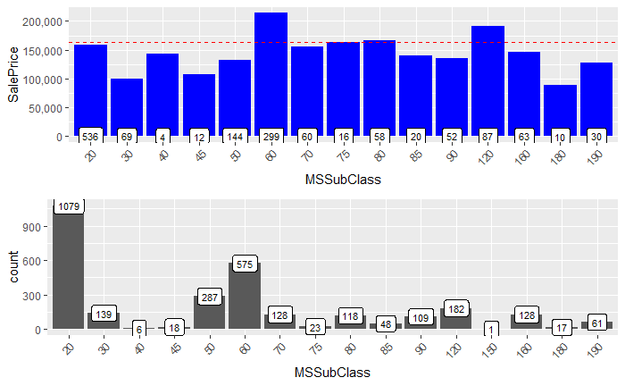

```r
grid.arrange(ms1, ms2)
```

```r
#correct error
all$GarageYrBlt[2593] <- 2007 #this must have been a typo. GarageYrBlt=2207, YearBuilt=2006, YearRemodAdd=2007
```

The last part is consdering that garage variables. Since garage related variables appeared few times in important variable chart.There are 3 major garage related variables explained here named GarageCars, GarageType, and a Quality measurement. Garage cars and garage area seems to be highly correlated. Garage Qual and condition are also highky correlated.

```r
g1 <- ggplot(data=all[all$GarageCars !=0,], aes(x=GarageYrBlt)) +
        geom_histogram()
g2 <- ggplot(data=all, aes(x=as.factor(GarageCars))) +
        geom_histogram(stat='count')
```

```
Ignoring unknown parameters: binwidth, bins, pad
```

```r
g3 <- ggplot(data= all, aes(x=GarageArea)) +
        geom_density()
g4 <- ggplot(data=all, aes(x=as.factor(GarageCond))) +
        geom_histogram(stat='count')
```

```
Ignoring unknown parameters: binwidth, bins, pad
```

```r
g5 <- ggplot(data=all, aes(x=GarageType)) +
        geom_histogram(stat='count')
```

```
Ignoring unknown parameters: binwidth, bins, pad
```

```r
g6 <- ggplot(data=all, aes(x=as.factor(GarageQual))) +
        geom_histogram(stat='count')
```

```
Ignoring unknown parameters: binwidth, bins, pad
```

```r
g7 <- ggplot(data=all, aes(x=as.factor(GarageFinish))) +
        geom_histogram(stat='count')
```

```
Ignoring unknown parameters: binwidth, bins, pad
```

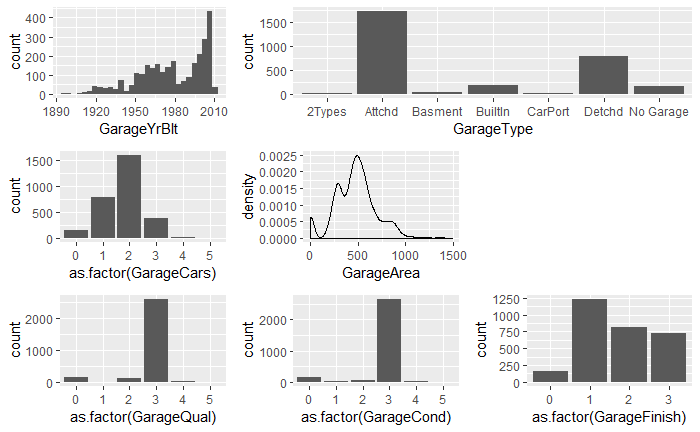

```r
layout <- matrix(c(1,5,5,2,3,8,6,4,7),3,3,byrow=TRUE)
multiplot(g1, g2, g3, g4, g5, g6, g7, layout=layout)
```